# ashishsa_hw1_p2

We first take a look at the Boston Housing Dataset.

```r
library(MASS)
data(Boston)
df1 <- Boston
head(df1)
```

```
##      crim zn indus chas   nox    rm  age    dis rad tax ptratio  black lstat
## 1 0.00632 18  2.31    0 0.538 6.575 65.2 4.0900   1 296    15.3 396.90  4.98
## 2 0.02731  0  7.07    0 0.469 6.421 78.9 4.9671   2 242    17.8 396.90  9.14
## 3 0.02729  0  7.07    0 0.469 7.185 61.1 4.9671   2 242    17.8 392.83  4.03
## 4 0.03237  0  2.18    0 0.458 6.998 45.8 6.0622   3 222    18.7 394.63  2.94
## 5 0.06905  0  2.18    0 0.458 7.147 54.2 6.0622   3 222    18.7 396.90  5.33
## 6 0.02985  0  2.18    0 0.458 6.430 58.7 6.0622   3 222    18.7 394.12  5.21
##   medv
## 1 24.0
## 2 21.6
## 3 34.7
## 4 33.4
## 5 36.2
## 6 28.7
```

For Market Basket Analysis using Apriori Algorithm its essential that all the variables that are continuous get converted into categorical. From the initial Observation we observe that crim,zn,indus,nox,rm,age,dis,tax,ptratio,black,lstat,medv are continuous variable which needs to be converted into categorical variables. We first compare the effect of various variables that effect medv. Also we check the effect of variables on each other by using the correlation plot. This tells us the effect of variables on each other.

```r
library(GGally)
```

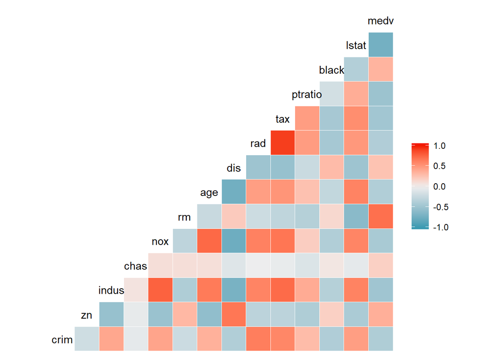

```r
ggcorr(df1,title="CORRELATION--PLOT")
```

Now After a basic pre-eliminary analysis of the dataset we now convert the dataset into a list for further operation.

```r
Boston_list <- as(Boston,"list")
library(qboxplot)
```

Now we check the histogram values for every variable and then use the information to convert the continuous variable to categorical variable.

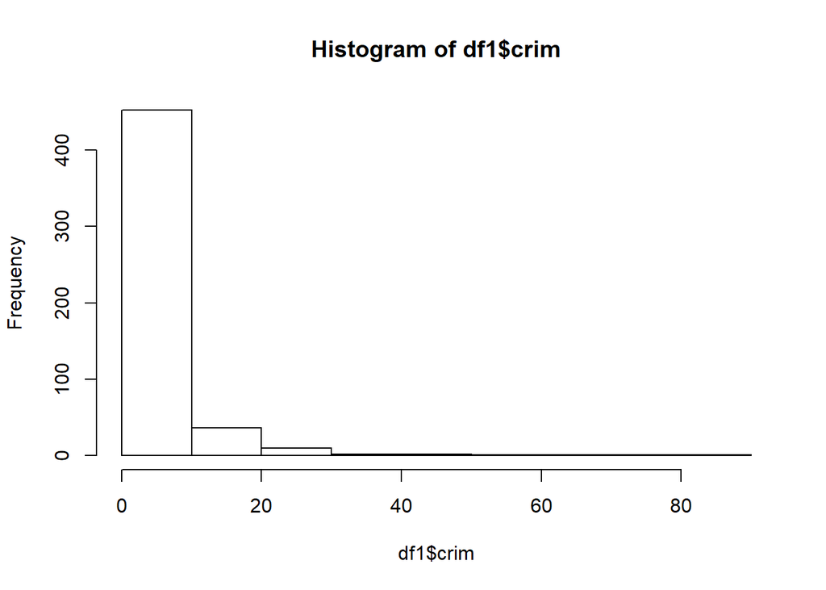

```r
hist(df1$crim)
```

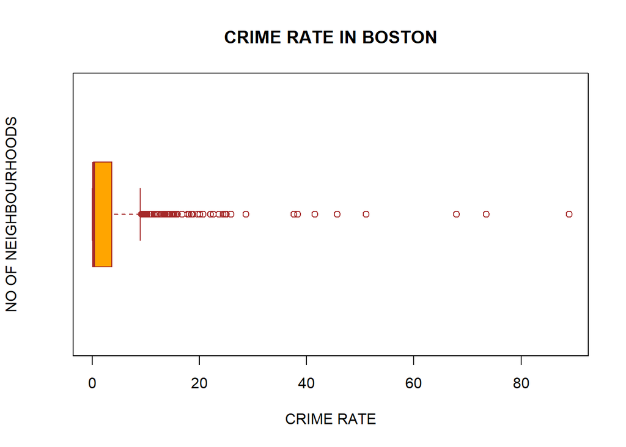

```r
b1 <- boxplot(df1$crim,
main = "CRIME RATE IN BOSTON",
xlab = "CRIME RATE",
ylab = "NO OF NEIGHBOURHOODS",
col = "orange",
border = "brown",
horizontal = TRUE,
notch = FALSE
)
```

We now check for the probability of crime rates using the Boxplot and Quantile function

```r
quantile(Boston$crim,probs = c(0,0.25,0.75,0.9,1))
```

```
##        0%       25%       75%       90%      100%
##  0.006320  0.082045  3.677083 10.753000 88.976200
```

```r
Boston[["crim"]] <-
ordered(cut(df1[["crim"]],c(0.006,0.083,3.67 ,10.75,88.97)),labels=c("Low-crim","Middle-crim","High-crim","Super-crim"))
```

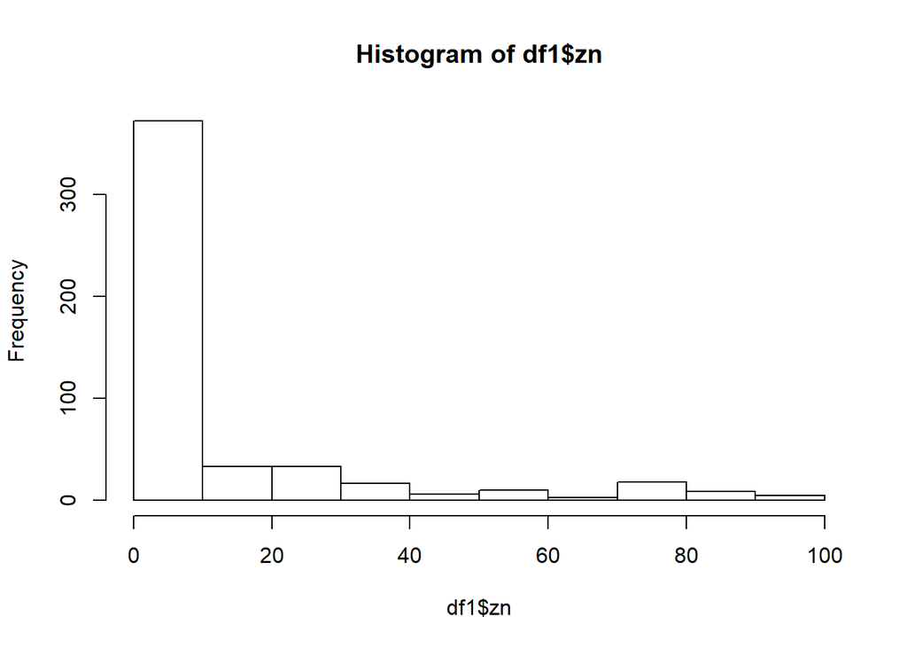

```r
hist(df1$zn)
```

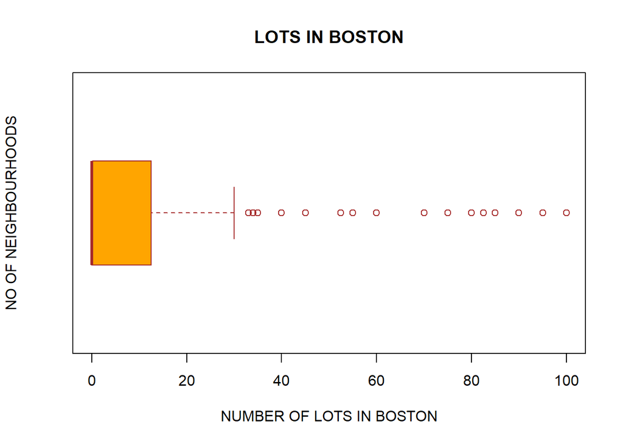

```r
b1 <- boxplot(df1$zn,
main = "LOTS IN BOSTON",
xlab = "NUMBER OF LOTS IN BOSTON",
ylab = "NO OF NEIGHBOURHOODS",
col = "orange",
border = "brown",
horizontal = TRUE,
notch = FALSE
)
```

We now check for the probability of Number Of Lots using the Boxplot and Quantile function

```r
quantile(Boston$zn,probs = c(0,0.75,0.85,0.95,1))
```

```
##    0%   75%   85%   95%  100%
##   0.0  12.5  28.0  80.0 100.0
```

```r
Boston[["zn"]] <- ordered(cut(Boston$zn,c(0.0,12.5,28.0,80.0,100.0)),labels=c("no-lot","low-lot","middle-lot","high-lot"))
```

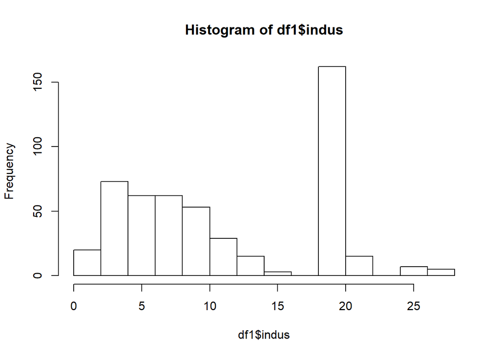

```r
hist(df1$indus)
```

We now check for the proportion of non-retail business acres per town using the Boxplot and Quantile function.

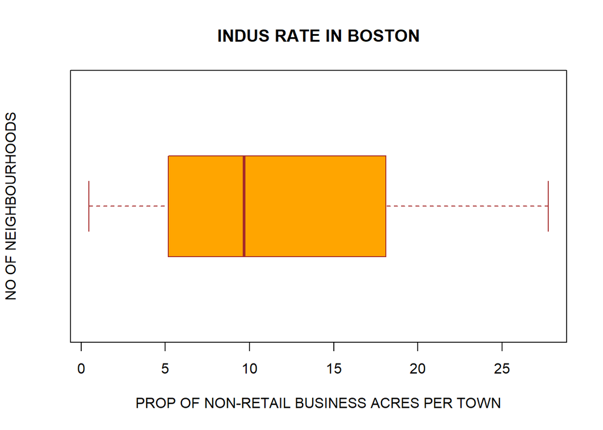

```r
b1 <- boxplot(df1$indus,
main = "INDUS RATE IN BOSTON",
xlab = "PROP OF NON-RETAIL BUSINESS ACRES PER TOWN",
ylab = "NO OF NEIGHBOURHOODS",
col = "orange",
border = "brown",
horizontal = TRUE,
notch = FALSE
)
```

```r
quantile(Boston$indus,probs = c(0,0.25,0.75,0.9,1))
```

```
##    0%   25%   75%   90%  100%
##  0.46  5.19 18.10 19.58 27.74
```

```r
Boston[["indus"]] <-
ordered(cut(df1[["indus"]],c(0.46,5.19,18.10 ,19.58,27.74)),labels=c("Low-indus","Middle-indus","High-indus","Super-indus"))
```

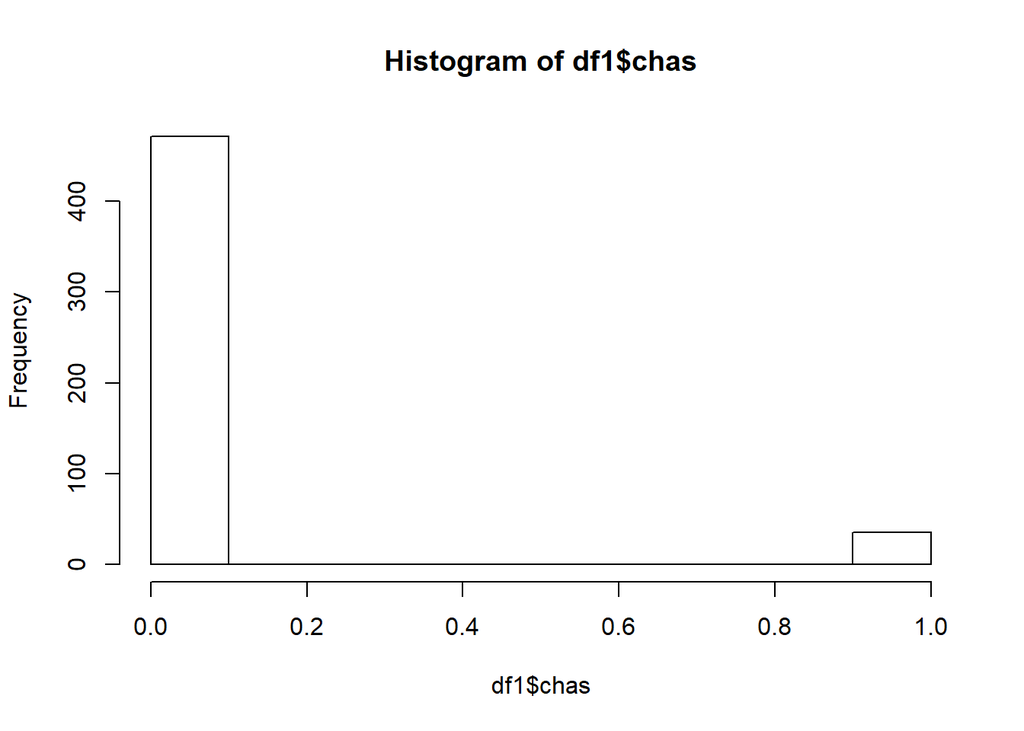

```r
hist(df1$chas)
```

We observe that most of the neighbourhoods do not track Charles River and very few neighbourhoods track Charles River.

We now check for the proportion of Neighbourhoods that track the Charles River.

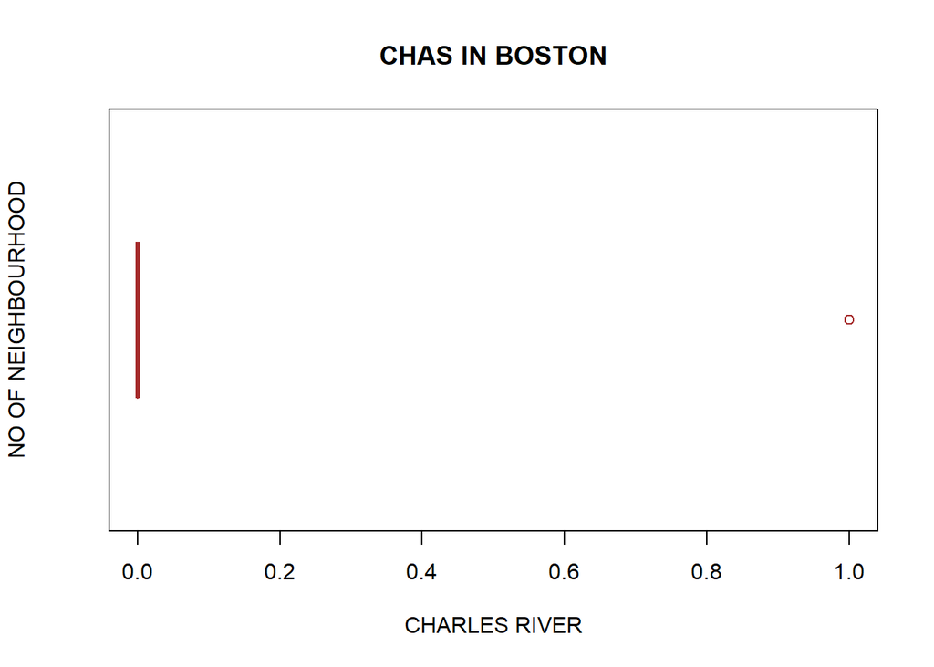

```r
b1 <- boxplot(df1$chas,
main = "CHAS IN BOSTON",
xlab = "CHARLES RIVER",
ylab = "NO OF NEIGHBOURHOOD",
col = "orange",
border = "brown",
horizontal = TRUE,
notch = FALSE
)
```

```r
Boston[["chas"]] <- ordered(Boston$chas,labels=c("off-river","near-river"))
```

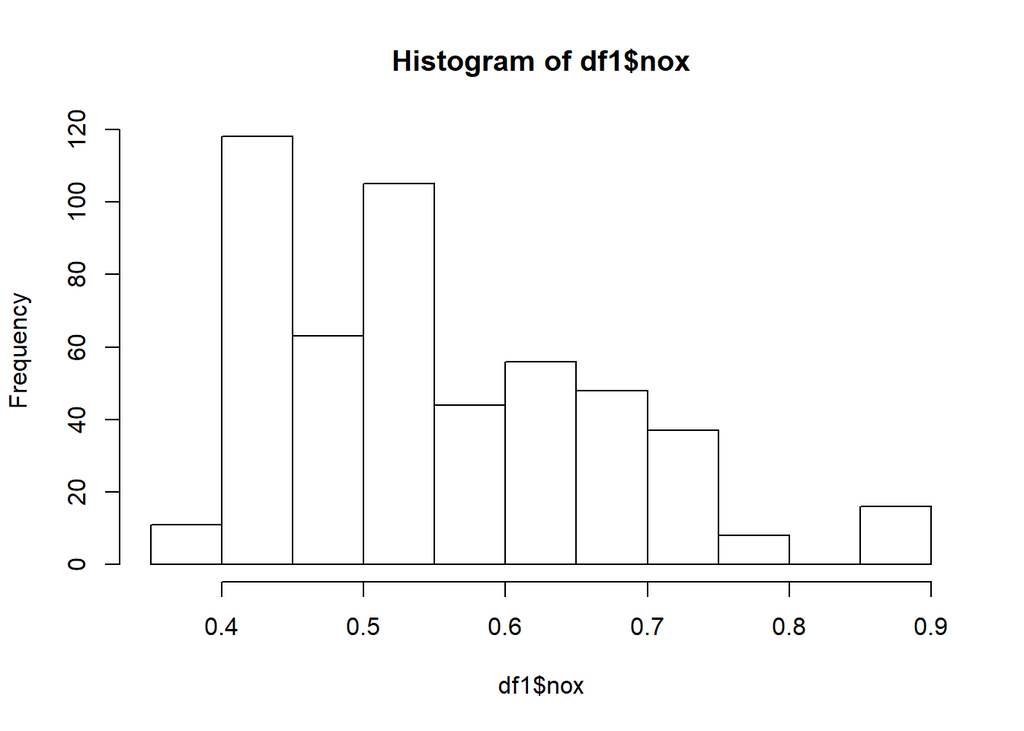

```r
hist(df1$nox)
```

We now check for the proportion of nitric oxides concentration.

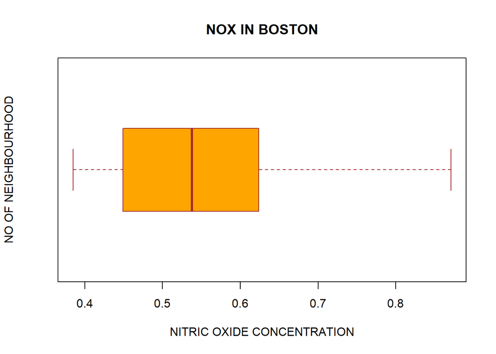

```r
b1 <- boxplot(df1$nox,
main = "NOX IN BOSTON",
xlab = "NITRIC OXIDE CONCENTRATION",
ylab = "NO OF NEIGHBOURHOOD",
col = "orange",
border = "brown",
horizontal = TRUE,
notch = FALSE
)
```

```r
quantile(Boston$nox,probs = c(0,0.25,0.75,0.9,1))
```

```
##    0%   25%   75%   90%  100%
## 0.385 0.449 0.624 0.713 0.871
```

```r
Boston[["nox"]] <-
ordered(cut(df1[["nox"]],c(0.385,0.449,0.624,0.713,0.871)),labels=c("Low-nox","Middle-nox","High-nox","Super-noxs"))
```

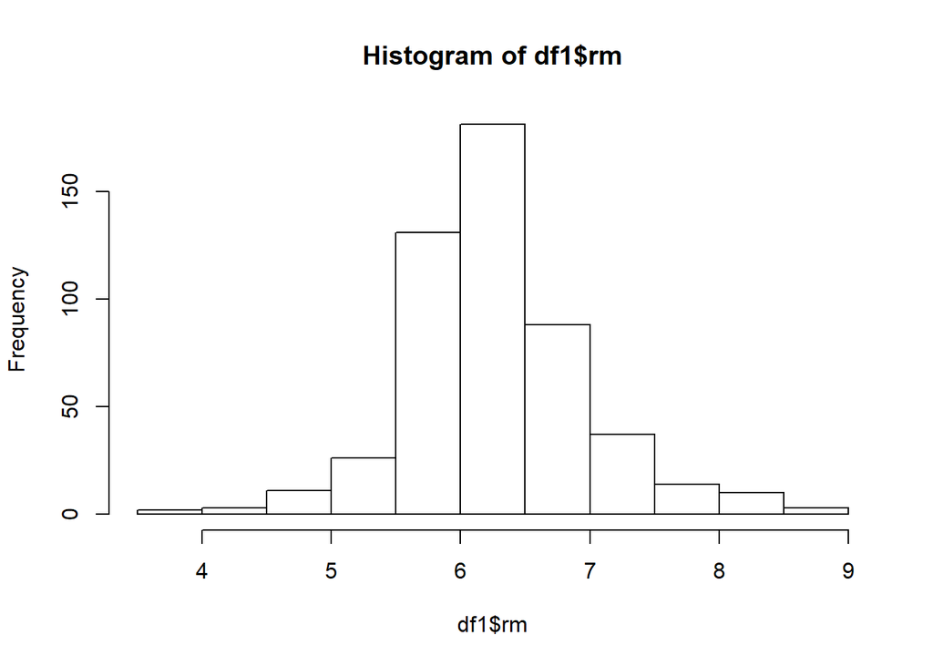

```r
hist(df1$rm)
```

We observe that most of the neighbourhoods have between 6-7 rooms and there are more number of neighbourhoods that have more than 7 rooms than neighbourhoods with less than 5 rooms.

We now check for the average number of rooms per dwelling.

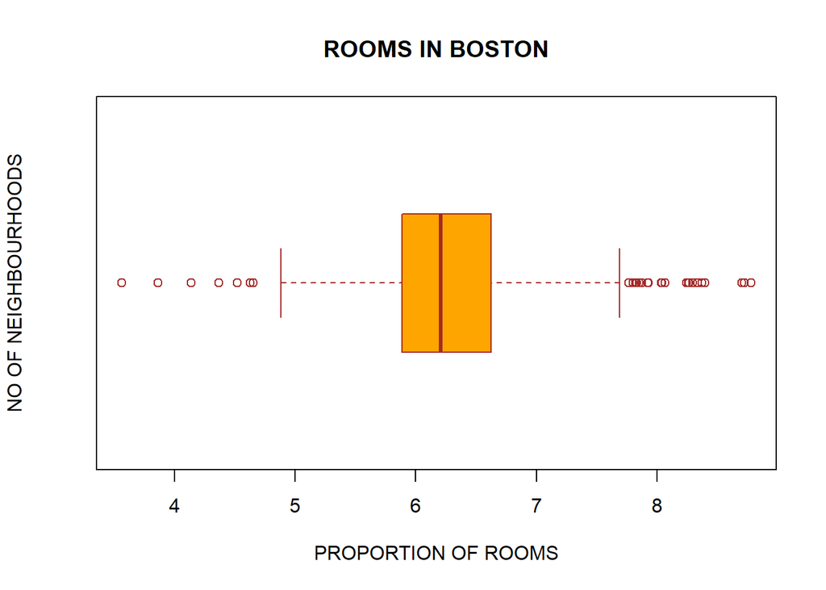

```r
b1 <- boxplot(df1$rm,
main = "ROOMS IN BOSTON",
xlab = "PROPORTION OF ROOMS",
ylab = "NO OF NEIGHBOURHOODS",
col = "orange",
border = "brown",
horizontal = TRUE,
notch = FALSE
)
```

```r
quantile(Boston$rm,probs = c(0,0.25,0.75,0.9,1))
```

```
##     0%    25%    75%    90%   100%
## 3.5610 5.8855 6.6235 7.1515 8.7800
```

```r
Boston[["rm"]] <-
ordered(cut(df1[["rm"]],c(3,5,7,9)),labels=c("small-house","Middle-house","big-house"))
```

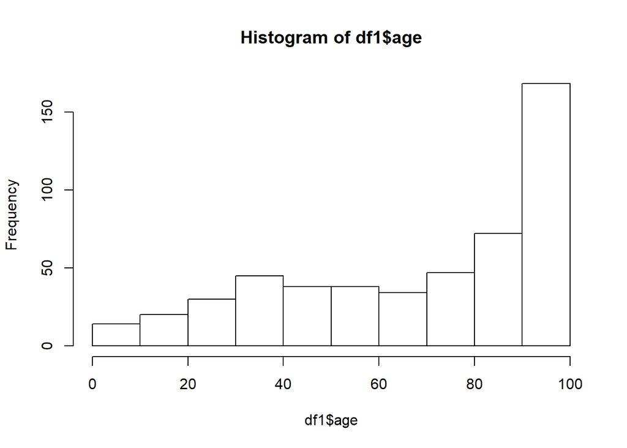

```r
hist(df1$age)
```

We now check for the proportion of owner-occupied units built prior to 1940.

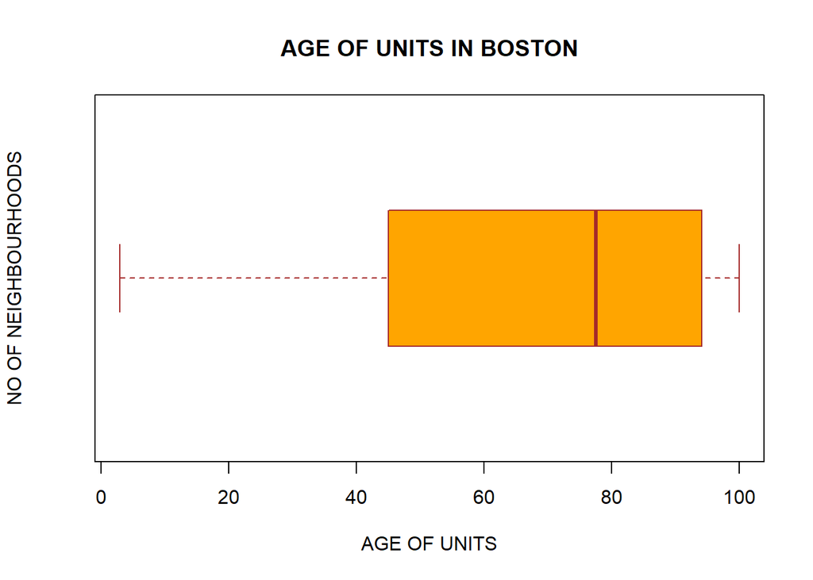

```r
b1 <- boxplot(df1$age,
main = "AGE OF UNITS IN BOSTON",
xlab = "AGE OF UNITS",
ylab = "NO OF NEIGHBOURHOODS",
col = "orange",
border = "brown",
horizontal = TRUE,
notch = FALSE
)
```

```r
quantile(Boston$age,probs = c(0,0.10,0.25,0.40,1))
```

```
##      0%     10%     25%     40%    100%
##   2.900  26.950  45.025  65.400 100.000
```

```r
Boston[["age"]] <-
ordered(cut(df1[["age"]],c(3,27,46,65,100)),labels=c("Young", "Middle-aged", "Senior", "Elderly"))
```

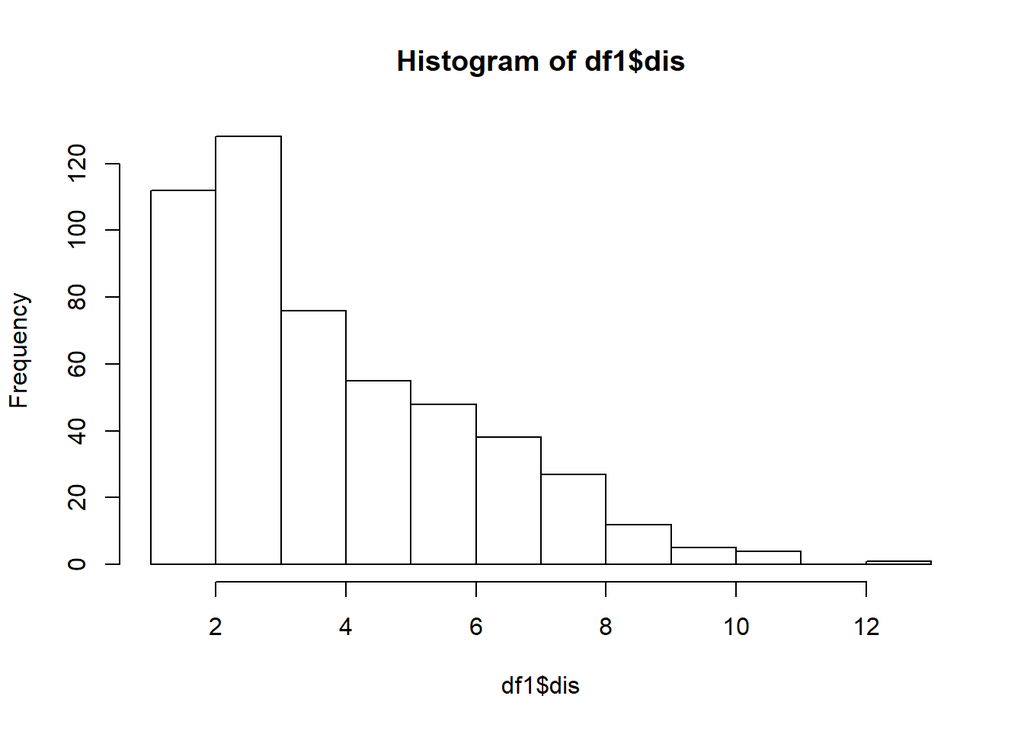

```r
hist(df1$dis)
```

We observed that maximum number of units have very low amount of distance between the units to Boston Employment Centers while most of the centres have an average distance between 3 to 8 miles. Again very few units are situated far away from the Boston Employment Center.

We now check for the proportion of weighted distances to five Boston employment centres.

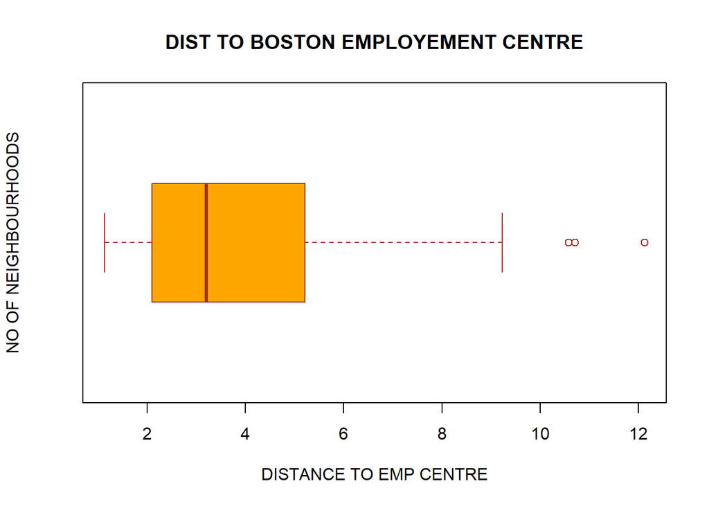

```r
b1 <- boxplot(df1$dis,
main = "DIST TO BOSTON EMPLOYEMENT CENTRE",
xlab = "DISTANCE TO EMP CENTRE",
ylab = "NO OF NEIGHBOURHOODS",
col = "orange",
border = "brown",
horizontal = TRUE,
notch = FALSE
)
```

```r
quantile(Boston$dis,probs = c(0,0.60,0.85,0.99,1))
```

```
##        0%       60%       85%       99%      100%
##  1.129600  3.875000  6.267675  9.222770 12.126500
```

```r
Boston[["dis"]] <-
ordered(cut(df1[["dis"]],c(1,4,7,10,12)),labels=c("Low-dis","Middle-dis","High-dis","Super-dis"))
```

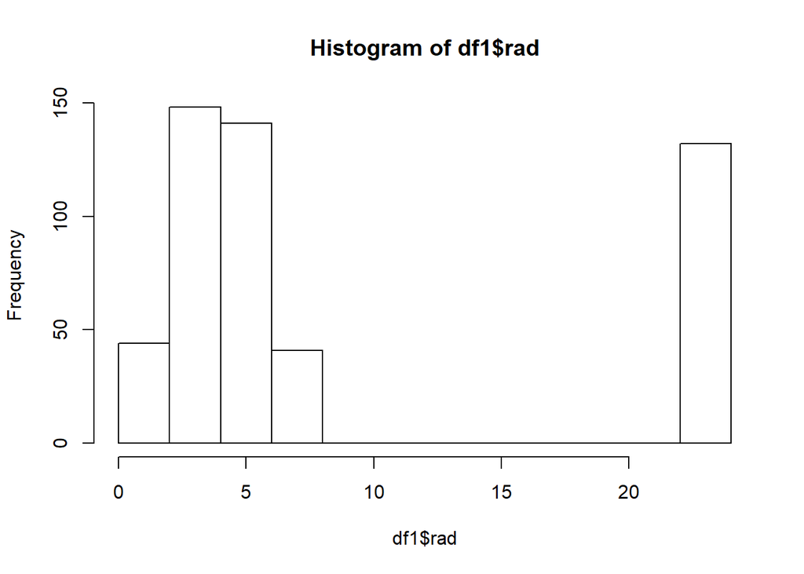

```r
hist(df1$rad)
```

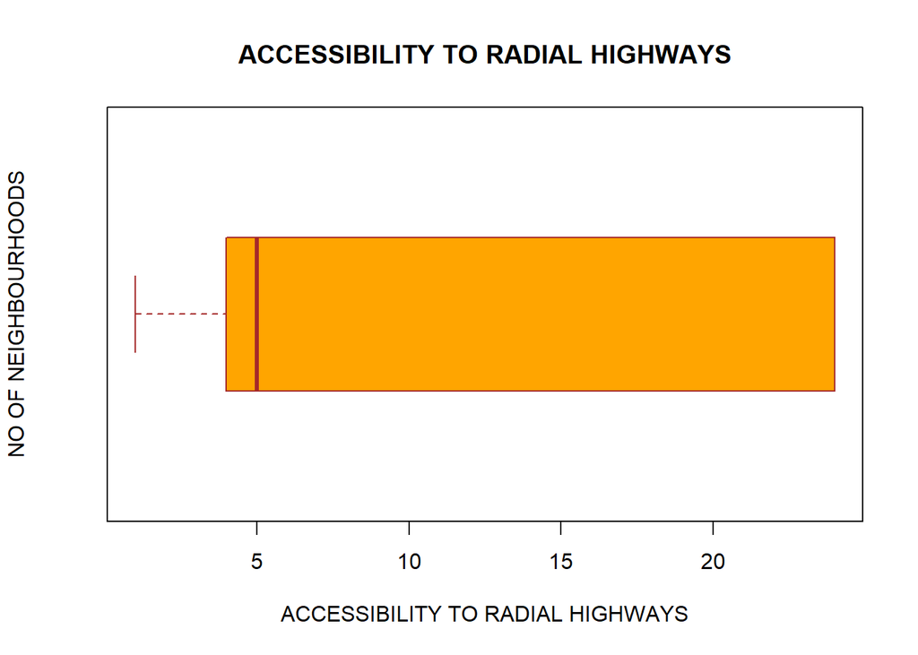

```r
b1 <- boxplot(df1$rad,
main = "ACCESSIBILITY TO RADIAL HIGHWAYS",
xlab = "ACCESSIBILITY TO RADIAL HIGHWAYS",
ylab = "NO OF NEIGHBOURHOODS",
col = "orange",
border = "brown",
horizontal = TRUE,
notch = FALSE
)
```

```r
quantile(Boston$rad,probs = c(0,0.25,0.5,0.70,1))
```

```
##   0%  25%  50%  70% 100%
##    1    4    5    8   24
```

```r
Boston[["rad"]] <-
ordered(cut(df1[["rad"]],c(1,4,5,8,24)),labels=c("Low-index","Middle-index","High-index","Super-index"))
```

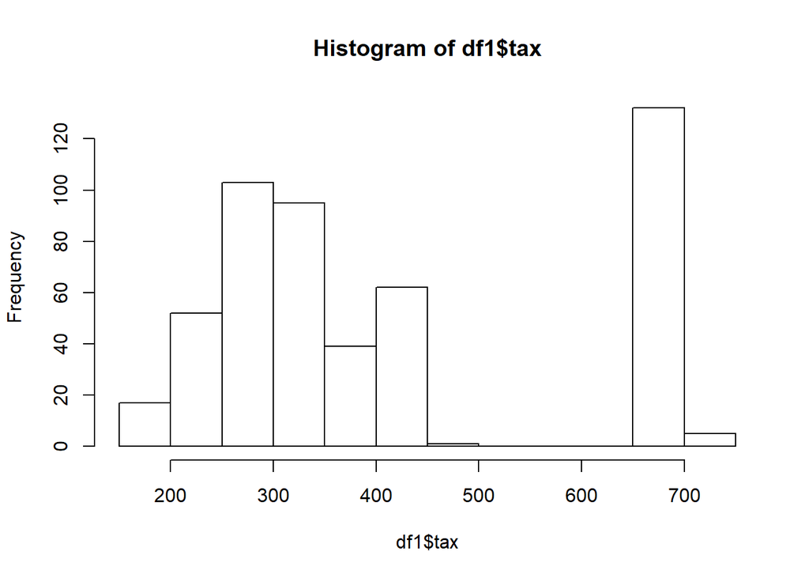

```r
hist(df1$tax)
```

We now check for the proportion of full-value property-tax rate per $10,000

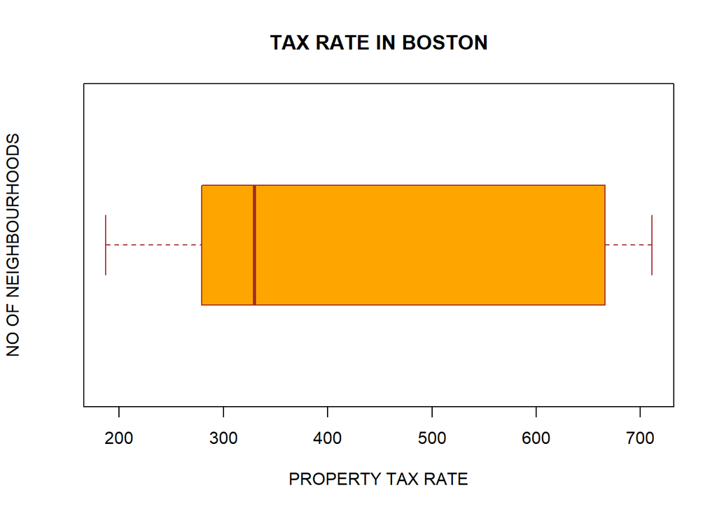

```r
b1 <- boxplot(df1$tax,
main = "TAX RATE IN BOSTON",
xlab = "PROPERTY TAX RATE",
ylab = "NO OF NEIGHBOURHOODS",
col = "orange",
border = "brown",
horizontal = TRUE,
notch = FALSE
)
```

```r
quantile(Boston$tax,probs = c(0,0.25,0.70,0.9,1))
```

```
##   0%  25%  70%  90% 100%
##  187  279  437  666  711
```

```r
Boston[["tax"]] <-
ordered(cut(df1[["tax"]],c(187,279,500,711)),labels=c("Low-tax","Middle-tax","High-tax"))
```

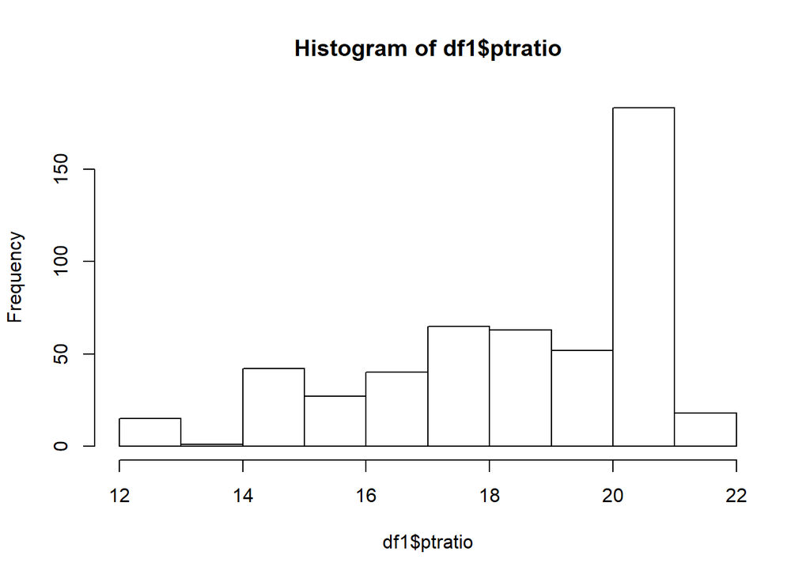

```r
hist(df1$ptratio)
```

We observe that most of the units in Boston has a pupil-teacher ratio of 20-21. The Average pupil-teacher ratio is between 14-20.

We now check for the proportion of pupil-teacher ratio by town.

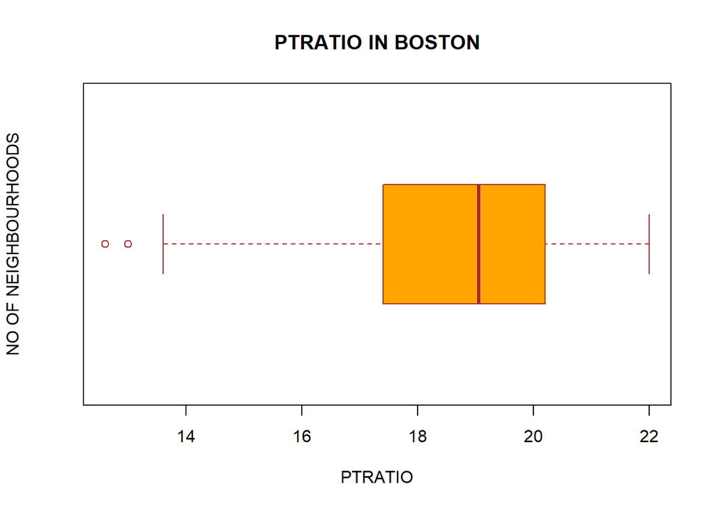

```r
b1 <- boxplot(df1$ptratio,
main = "PTRATIO IN BOSTON",
xlab = "PTRATIO",
ylab = "NO OF NEIGHBOURHOODS",
col = "orange",
border = "brown",
horizontal = TRUE,
notch = FALSE
)
```

```r
quantile(Boston$ptratio,probs = c(0,0.25,0.75,0.9,1))
```

```
##   0%  25%  75%  90% 100%
## 12.6 17.4 20.2 20.9 22.0
```

```r
Boston[["ptratio"]] <-
ordered(cut(Boston[["ptratio"]],c(12.6,17.4,20.2,22)),labels=c("Low-ptratio","Middle-ptratio","High-ptratio"))
```

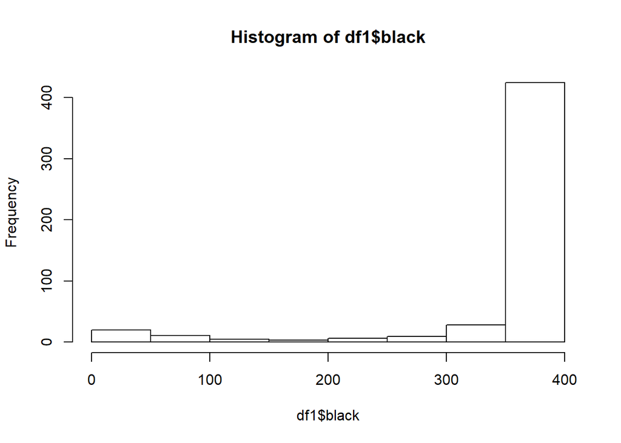

```r
hist(df1$black)
```

Most of the neighbourhoods have between 350-400 Black citizens in Boston.

We now check for the proportion of blacks by town.

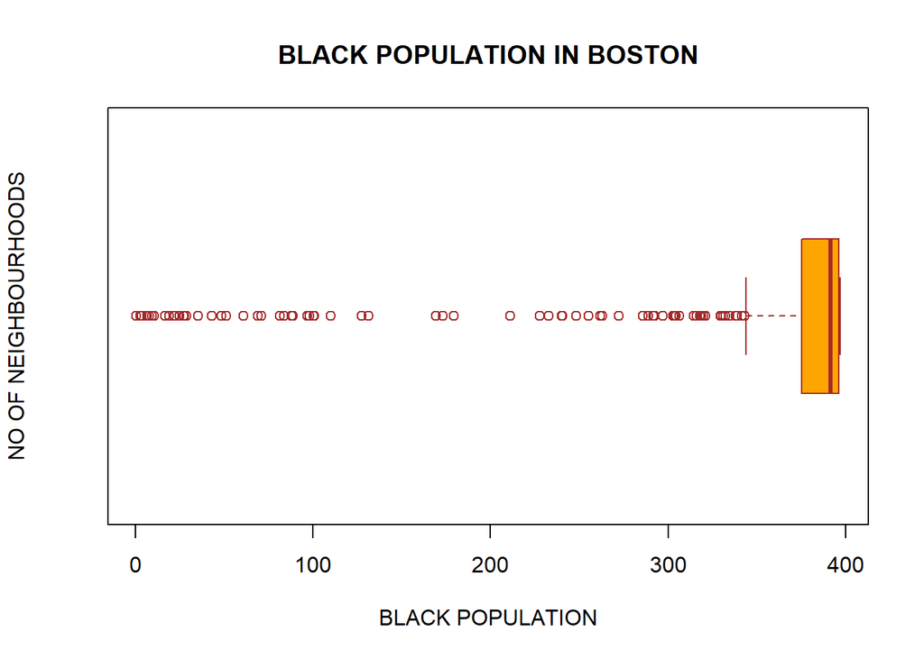

```r
b1 <- boxplot(df1$black,
main = "BLACK POPULATION IN BOSTON",
xlab = "BLACK POPULATION",
ylab = "NO OF NEIGHBOURHOODS",
col = "orange",
border = "brown",
horizontal = TRUE,
notch = FALSE
)
```

```r
quantile(Boston$black,probs = c(0,0.06,0.11,1))
```

```
##       0%       6%      11%     100%
##   0.3200  98.6220 303.8545 396.9000
```

```r
Boston[["black"]] <-
ordered(cut(Boston[["black"]],c(0,100,300,400)),labels=c("Low-black","Middle-black","High-black"))
```

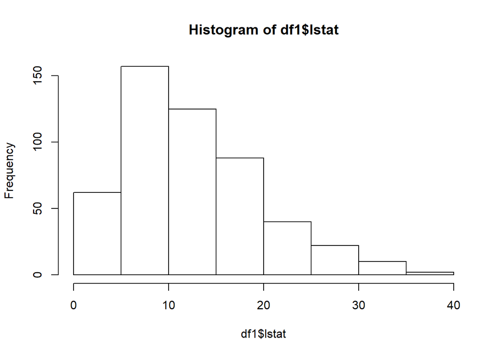

```r
hist(df1$lstat)
```

The maximum frequency of population belong to 5-25 percentage of lower population.

We now check for the proportion of lower status of the population

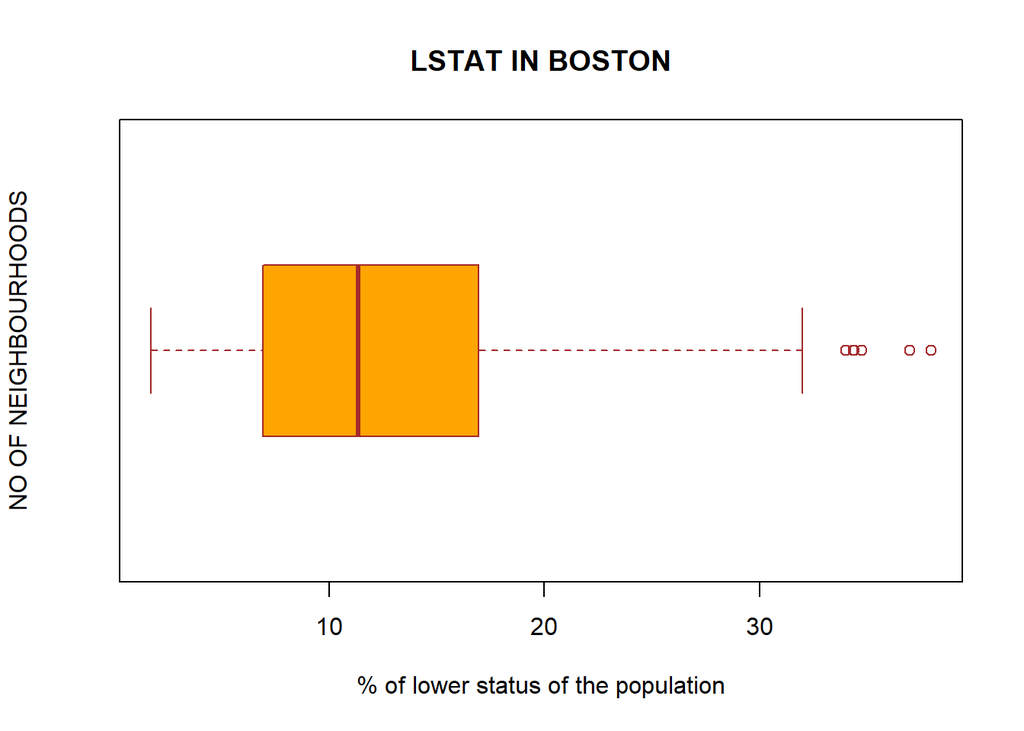

```r
b1 <- boxplot(df1$lstat,
main = "LSTAT IN BOSTON",
xlab = "% of lower status of the population",
ylab = "NO OF NEIGHBOURHOODS",
col = "orange",
border = "brown",
horizontal = TRUE,
notch = FALSE
)
```

```r
quantile(Boston$lstat,probs = c(0,0.45,0.75,0.9,1))
```

```
##      0%     45%     75%     90%    100%
##  1.7300 10.2625 16.9550 23.0350 37.9700
```

```r
Boston[["lstat"]] <-
ordered(cut(Boston[["lstat"]],c(1,10,20,40)),labels=c("Low-lstat","Middle-lstat","High-lstat"))
```

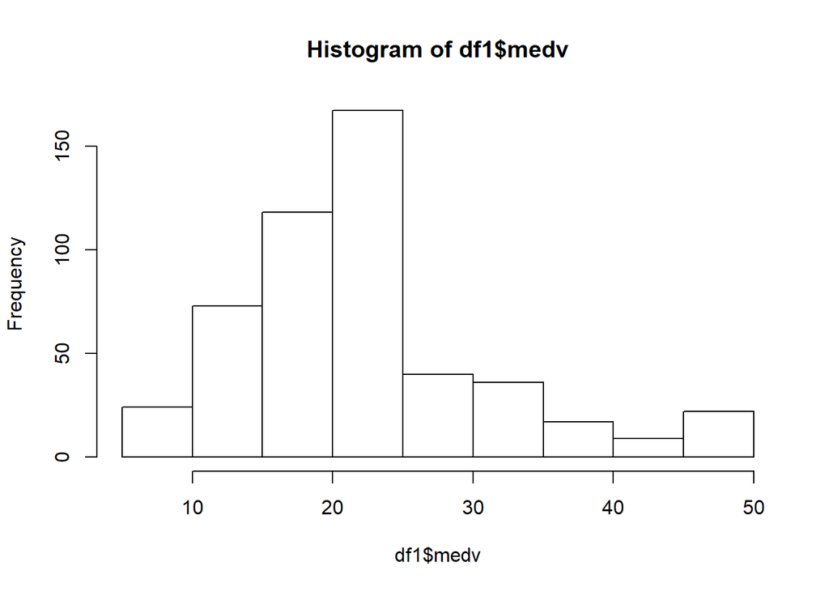

```r
hist(df1$medv)
```

We now check for the proportion of Median value of owner-occupied homes in $1000’s

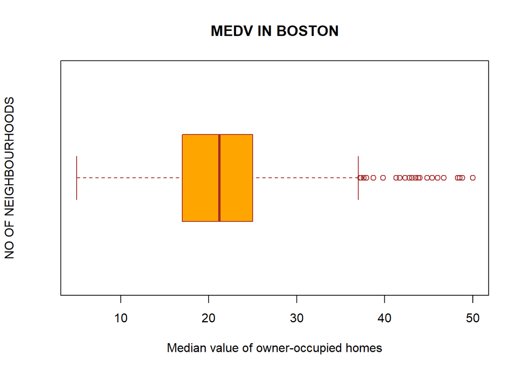

```r
b1 <- boxplot(df1$medv,
main = "MEDV IN BOSTON",
xlab = "Median value of owner-occupied homes",
ylab = "NO OF NEIGHBOURHOODS",
col = "orange",
border = "brown",
horizontal = TRUE,
notch = FALSE
)
```

```r
quantile(Boston$medv,probs = c(0,0.25,0.75,0.9,1))
```

```
##     0%    25%    75%    90%   100%
##  5.000 17.025 25.000 34.800 50.000
```

```r
Boston[["medv"]] <-
ordered(cut(Boston[["medv"]],c(0,15,25,40,55)),labels=c("Low-value","Middle-value","High-value","super-value"))
```

We need to transform the data into Binary Incidence Matrix. This Binary Incidence Matrix helps us to find the important relationship between various variables in the dataset.

```r
library(arules)
Boston_data <- as(Boston,"transactions")
summary(Boston_data)
```

```
## transactions as itemMatrix in sparse format with
##  506 rows (elements/itemsets/transactions) and
##  49 columns (items) and a density of 0.269541
##
## most frequent items:
##     chas=off-river   black=High-black    rm=Middle-house        dis=Low-dis
##                471                452                426                316
## indus=Middle-indus            (Other)
##                315               4703
##
## element (itemset/transaction) length distribution:
## sizes
##  12  13  14
##  10 381 115
##
##    Min. 1st Qu.  Median    Mean 3rd Qu.    Max.
##   12.00   13.00   13.00   13.21   13.00   14.00
##
## includes extended item information - examples:
##             labels variables      levels
## 1    crim=Low-crim      crim    Low-crim
## 2 crim=Middle-crim      crim Middle-crim
## 3   crim=High-crim      crim   High-crim
##
## includes extended transaction information - examples:
##   transactionID
## 1             1
## 2             2
## 3             3
```

We need to visualize the data using the item Frequency Plot. We visualize the data in the descending order of support. Inorder to see how variables are getting added as the support decreases.

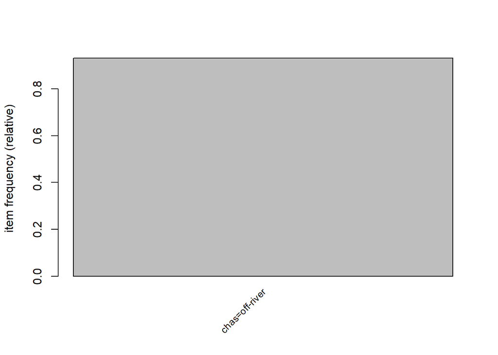

```r
itemFrequencyPlot(Boston_data,support=0.9,cex.name=0.8)
```

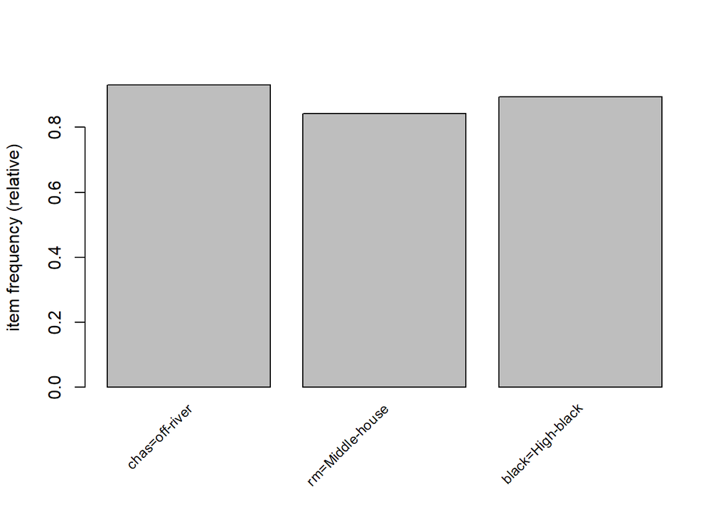

```r
itemFrequencyPlot(Boston_data,support=0.7,cex.name=0.8)
```

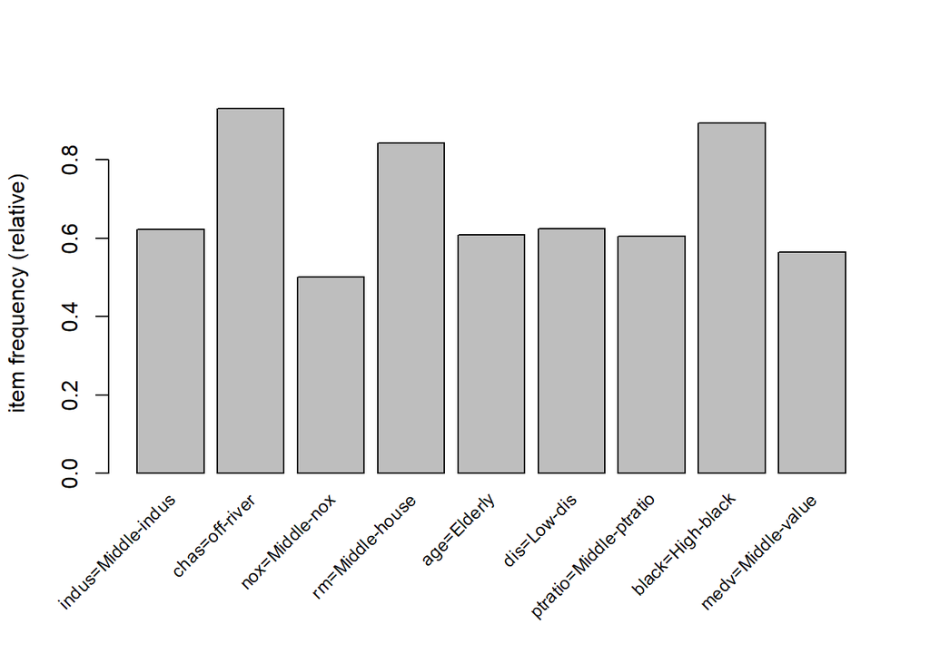

```r
itemFrequencyPlot(Boston_data,support=0.5,cex.name=0.8)
```

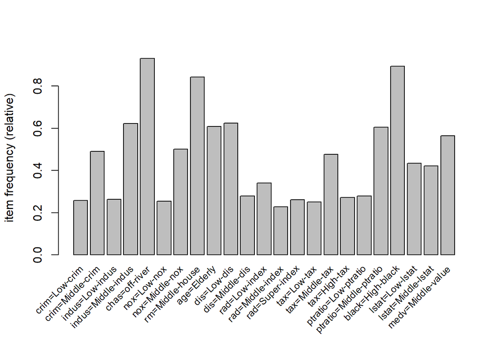

```r
itemFrequencyPlot(Boston_data,support=0.2,cex.name=0.8)
```

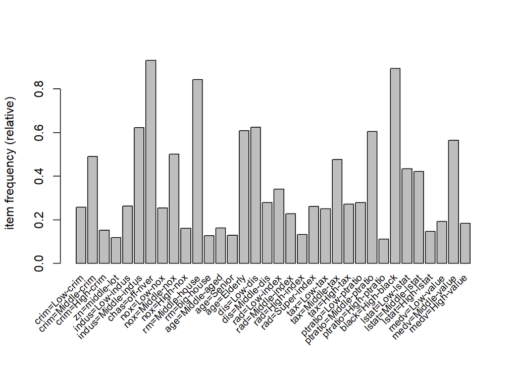

```r
itemFrequencyPlot(Boston_data,support=0.1,cex.name=0.8)
```

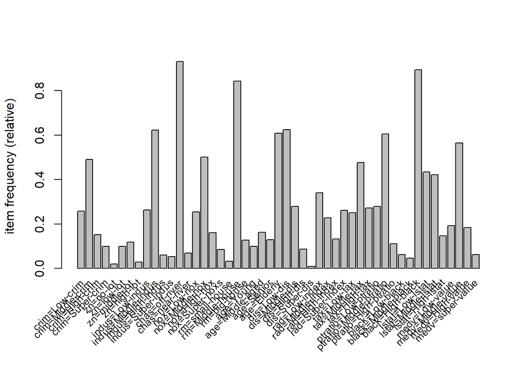

```r
itemFrequencyPlot(Boston_data,support=0,cex.name=0.8)
```

We now use Apriori Algorithm to find the rules that affect the effects of each variable on one another.

```r
rules <- apriori(Boston_data,parameter = list(support=0.02,confidence=0.1))
```

```
## Apriori
##
## Parameter specification:
##  confidence minval smax arem  aval originalSupport maxtime support minlen
##         0.1    0.1    1 none FALSE            TRUE       5    0.02      1
##  maxlen target   ext
##      10  rules FALSE
##
## Algorithmic control:
##  filter tree heap memopt load sort verbose
##     0.1 TRUE TRUE  FALSE TRUE    2    TRUE
##
## Absolute minimum support count: 10
##
## set item appearances ...[0 item(s)] done [0.00s].
## set transactions ...[49 item(s), 506 transaction(s)] done [0.00s].
## sorting and recoding items ... [47 item(s)] done [0.00s].
## creating transaction tree ... done [0.00s].
## checking subsets of size 1 2 3 4 5 6 7 8 9 10
```

```
##  done [0.03s].
## writing ... [515981 rule(s)] done [0.11s].
## creating S4 object  ... done [0.18s].
```

We now look at the summary of the data.

```r
summary(rules)
```

```
## set of 515981 rules
##
## rule length distribution (lhs + rhs):sizes
##      1      2      3      4      5      6      7      8      9     10
##     34   1093   9992  41012  92230 127290 117108  76824  37278  13120
##
##    Min. 1st Qu.  Median    Mean 3rd Qu.    Max.
##   1.000   5.000   6.000   6.439   7.000  10.000
##
## summary of quality measures:
##     support          confidence          lift             count
##  Min.   :0.02174   Min.   :0.1000   Min.   : 0.1902   Min.   : 11.00
##  1st Qu.:0.02372   1st Qu.:0.5926   1st Qu.: 1.1179   1st Qu.: 12.00
##  Median :0.03162   Median :0.8462   Median : 1.6013   Median : 16.00
##  Mean   :0.04191   Mean   :0.7687   Mean   : 1.9974   Mean   : 21.21
##  3rd Qu.:0.04743   3rd Qu.:1.0000   3rd Qu.: 2.2000   3rd Qu.: 24.00
##  Max.   :0.93083   Max.   :1.0000   Max.   :16.8667   Max.   :471.00
##
## mining info:
##         data ntransactions support confidence
##  Boston_data           506    0.02        0.1
```

We now use the rules generated using the Apriori Algorithm to find the low crime areas which are as close to the city as possible.

These rules gives us valuable insight into the association rules that are associated with the decisions to find the areas close to city and also having low crimes.

```r
Lowcrime_rules<-subset(rules,subset = lhs %in% "dis=Low-dis" & rhs %in% "crim=Low-crim" & lift>1)
```

```r
Lowcrime_rules
```

```
## set of 357 rules
```

To advise the student we take a look at the top 5 association rules that affect the decision that needs to be taken to stay as cloase as the city as possible while having the lowest crime.

```r
inspect(head(sort(Lowcrime_rules, by = "confidence"), n = 5))
```

```
##     lhs                         rhs                support confidence     lift count
## [1] {indus=Low-indus,
##      nox=Middle-nox,
##      dis=Low-dis,
##      ptratio=Middle-ptratio,
##      lstat=Low-lstat}        => {crim=Low-crim} 0.02173913  0.8461538 3.293491    11
## [2] {indus=Low-indus,
##      nox=Middle-nox,
##      dis=Low-dis,
##      tax=Low-tax,
##      ptratio=Middle-ptratio,
##      lstat=Low-lstat}        => {crim=Low-crim} 0.02173913  0.8461538 3.293491    11
## [3] {indus=Low-indus,
##      nox=Middle-nox,
##      dis=Low-dis,
##      ptratio=Middle-ptratio,
##      black=High-black,
##      lstat=Low-lstat}        => {crim=Low-crim} 0.02173913  0.8461538 3.293491    11
## [4] {indus=Low-indus,
##      chas=off-river,
##      nox=Middle-nox,
##      dis=Low-dis,
##      ptratio=Middle-ptratio,
##      lstat=Low-lstat}        => {crim=Low-crim} 0.02173913  0.8461538 3.293491    11
## [5] {indus=Low-indus,
##      nox=Middle-nox,
##      dis=Low-dis,
##      tax=Low-tax,
##      ptratio=Middle-ptratio,
##      black=High-black,
##      lstat=Low-lstat}        => {crim=Low-crim} 0.02173913  0.8461538 3.293491    11
```

These rules gives us valuable insight into the association rules that are associated with the decisions to find the schools with low student-pupil ratio.

```r
Lowptratio_rules <- subset(rules,subset=rhs %in% "ptratio=Low-ptratio" & lift > 1)
```

We observe that there are 7049 rules that affect it.

```r
Lowptratio_rules
```

```
## set of 7049 rules
```

To advise the student we take a look at the top 5 association rules that affect the decision that needs to be taken to find schools having the lowest pupil-teacher ratio.

```r
inspect(head(sort(Lowptratio_rules, by = "confidence"), n = 5))
```

```
##     lhs                     rhs                      support confidence     lift count
## [1] {indus=High-indus}   => {ptratio=Low-ptratio} 0.05928854          1 3.588652    30
## [2] {indus=High-indus,
##      nox=Super-noxs}     => {ptratio=Low-ptratio} 0.03162055          1 3.588652    16
## [3] {indus=High-indus,
##      rad=Middle-index}   => {ptratio=Low-ptratio} 0.05928854          1 3.588652    30
## [4] {indus=High-indus,
##      lstat=Middle-lstat} => {ptratio=Low-ptratio} 0.02766798          1 3.588652    14
## [5] {indus=High-indus,
##      tax=Middle-tax}     => {ptratio=Low-ptratio} 0.05928854          1 3.588652    30
```

We now use Regression to find the results and compare the results of Association Rules using Apriori Algorithm.

```r
library(caret)
library(MASS)
data(Boston)
#View(Boston)
set.seed(123)

amount_division <- createDataPartition(Boston$medv, p=2/3,list=FALSE)

training_dataset <- Boston[amount_division,]

#training_dataset <- as.matrix(training_dataset[,-11])

Y_training_dataset <- Boston$ptratio[amount_division]

testing_dataset <- Boston[-amount_division,]

Y_testing_dataset <- testing_dataset$ptratio

#testing_dataset <- as.matrix(testing_dataset[,-11])

grid = 10 ^ seq(-3 , 3 , length = 100)

Training_Parameters <- trainControl(method = "cv" ,
                                   number = 5 ,
                                   savePredictions = TRUE,
                                   verboseIter = TRUE)
#nrow(training_dataset)
#View(training_dataset)
df1 <- as.data.frame(training_dataset)

Ridge_Model <- train(ptratio~.,
                     data = df1 ,
                     method = "glmnet" ,
                     trControl = Training_Parameters ,
                     tuneGrid = data.frame(alpha = 0 , lambda = grid))
Ridge_Model$bestTune
```

```
##    alpha lambda
## 34     0    0.1
```

```r
#View(Ridge_Model$coefnames)
```

```r
Predict_Ridge_Model1 = predict(Ridge_Model, newdata = testing_dataset, s=Ridge_Model$bestTune)
Predict_Ridge_Model1
```

```
##        3        6        7        8        9       11       15       18
## 17.52929 18.17980 18.10677 17.75766 18.46750 18.72928 18.79297 18.73484
##       21       27       29       31       32       33       36       37
## 19.05593 18.87987 18.74158 19.03236 19.14481 18.62268 19.03113 18.83383
##       41       42       45       50       51       56       58       63
## 15.63320 18.09188 18.77928 18.97231 18.46394 15.47679 15.70491 18.75157
##       64       68       69       74       78       82       86       89
## 18.22548 18.82328 19.23046 18.88736 19.37923 18.39733 18.42184 18.47057
##       90       92       95       96      100      101      104      105
## 17.85050 18.51398 18.44364 18.18100 17.76091 18.26303 18.98420 18.95929
##      109      111      114      116      120      127      128      130
## 19.00602 18.54702 18.95875 18.94764 18.81851 18.27302 18.57223 18.70209
##      131      133      137      138      140      142      146      147
## 18.37120 18.07234 18.41696 18.49730 18.36611 18.37121 16.30109 16.49230
##      151      152      155      166      167      171      173      174
## 16.16830 16.42467 16.11630 17.96275 15.91046 18.59665 18.62118 18.60186
##      175      176      178      179      196      203      208      210
## 18.62207 17.81549 18.52101 17.99025 14.30317 14.77827 18.58009 18.55509
##      212      215      219      221      222      223      224      234
## 18.50429 17.73198 18.11496 18.29972 18.53131 18.15115 18.40228 16.65509
##      235      236      239      240      241      244      246      250
## 17.98019 18.74733 18.14112 18.30774 18.37489 18.09805 19.07500 18.23045
##      252      254      257      259      260      261      263      269
## 18.38526 16.63761 14.76375 15.88428 16.47991 15.92133 14.65199 15.59118
##      271      272      273      275      280      282      285      289
## 18.06236 17.65981 17.96778 16.54874 17.21489 17.20742 15.38499 18.03389
##      291      301      307      309      314      315      316      323
## 16.38610 17.28960 17.14976 18.46760 18.52424 18.29663 18.92270 18.88235
##      330      336      338      339      340      342      348      355
## 18.66288 18.42972 18.78078 18.48055 18.65279 16.70459 16.60924 17.23829
##      358      361      367      370      373      378      379      389
## 18.74712 18.92106 19.58218 17.65580 17.21318 20.39422 20.26284 20.34037
##      390      393      394      399      400      401      403      405
## 20.49300 20.51920 20.36314 20.61467 20.49068 20.71130 20.37779 20.19552
##      406      409      411      413      417      422      425      435
## 20.54173 20.58373 20.56208 20.07903 20.29774 20.09362 20.91784 20.07974
##      437      439      443      445      447      449      453      455
## 19.85641 19.60386 19.61984 19.90263 19.77477 20.13481 19.94578 19.59318
##      460      463      466      468      469      473      474      475
## 19.64319 19.67045 19.88341 20.62744 20.52936 20.36554 19.45397 21.23049
##      482      484      490      493      496      498      501      505
## 20.83041 20.80734 19.67490 18.70198 17.78123 18.57451 18.73902 17.97603
```

```r
actuals_preds <- data.frame(cbind(actuals=testing_dataset$ptratio, predicteds=Predict_Ridge_Model1))
head(actuals_preds)
```

```
##    actuals predicteds
## 3     17.8   17.52929
## 6     18.7   18.17980
## 7     15.2   18.10677
## 8     15.2   17.75766
## 9     15.2   18.46750
## 11    15.2   18.72928
```

```r
correlation_accuracy <- cor(actuals_preds)
correlation_accuracy
```

```
##              actuals predicteds
## actuals    1.0000000  0.6784229
## predicteds 0.6784229  1.0000000
```

```r
linear_information <- postResample(Predict_Ridge_Model1 , testing_dataset$ptratio)
linear_information
```

```
##      RMSE  Rsquared       MAE
## 1.5940896 0.4602577 1.2370170
```